# Project 2

Purchases data

Sciper 359523

# 1 Introduction

In today’s data-driven world, businesses are constantly seeking new ways to leverage customer data to make informed decisions and drive growth[1]. One area where data analysis can prove particularly useful is in forecasting customer purchases. By analyzing data on user behavior and purchase history, businesses can gain insights into what products or services customers are likely to buy in the future. Users’ reactions are therefore scrutinized to improve sales by better tailoring the ads.

In this report, we work with a data set providing us several variable such as an outcome variable we want to model, which is a binary indicator of a purchase being made or not. The other variables, that will help build the model are mostly divided between the users’ actions recorded by the websites, and the user’s personal characteristics.

In this report, we explore the use of a logistic regression model to predict purchase behavior based on user actions and personal characteristics. Our data set includes several variables, including a binary indicator of whether a purchase was made or not, as well as other user behavior and personal characteristics that serve as predictors.

The outline of the remainder of this report is as follows. We introduce the data in section 2, describe our model selection procedure in section 3 and present the final model. We analyse our model via the diagnostics in Section 4 and will compare it to other in section 5. In section 6 we conclude on the work done and the potential improvements.

# 2 Data characteristics

The outcome of interest is the fact that a purchase was made or not (variable *purchase*). The data set is composed of several different features that can be decomposed in three main groups :

1. Data coming from the e-commerce website :
- The number of administrative-type pages that the user visited and the time spent on them (numerical variable)
- The number of informational-type pages that the user visited and the time spent on them (numerical variable)
- The number of product-related-type pages that the user visited and the time spent on them (numerical variable)
2. Data derived from the date :
- The month in which the session took place (categorical variable with 10 levels)
- An indicator of whether the session took place during the week-end or not (dummy variable)
- An indicator between [0,1] evaluating the closeness to a special day (numerical variable)
3. Data coming from Google Analytics :
- The average bounce rate of pages visited (numerical variable)
- The average exit rate of pages visited (numerical variable)
- The average page value of pages visited (numerical variable)
- The operating systems of the user (categorical variable with 8 levels)
- The web browsers of the users (categorical variable with 13 levels)
- The geographic region in which the use is located (categorical variable with 9 levels)
- Where from the user arrived at the site (categorical variable with 20 levels)
- The type of visitor (categorical variable with 3 levels)

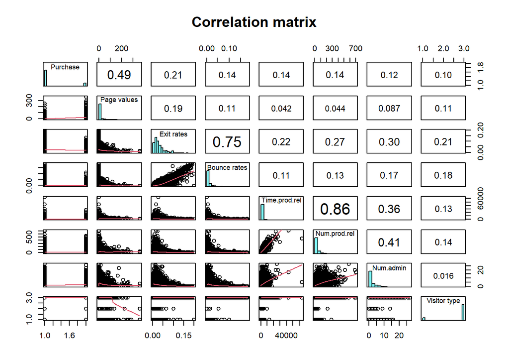

Figure 1 : Correlation matrix

Additional descriptive statistics show that purchases in the database represent 16.4 % of the data set and are predominantly made by returning visitors. While no particular region stands out, there are noticeable differences in purchasing behavior depending on the browser and traffic type used. Users who make a purchase tend to view more pages and have lower exit and bounce rates compared to those who do not make a purchase. Furthermore, they tend to spend more time on the website and engage more with the content. Surprisingly, weekends and special days do not seem to have a significant effect on sales, although the session month does.

Given these findings, we consider several data set transformations to improve our models. Some categorical variables contain only a few observations for each level, so we use clustering to group levels and increase the sample size. In addition, certain variables are over-dispersed, so we explore log and square root transformations to construct more accurate models.

In summary, the clustered variables are as follows :

- Traffic type
- Browser
- Operating systems

The added variables are as follows :

- The log and square root of the exit rate
- The log and square root of the bounce rates
- The log and square root of the number of administrative pages consulted and the log and square root of the time spent on those pages
- The log of the number of product related pages consulted and the log and square root of the time spent on each
- The log of the informative duration
- The log of the page values

Finally, I added variables accounting for interactions between the number of pages visited and the time spent on each, for each category of pages (administrative, product related, informative).

# 3 Model selection

To build the model, I start by computing the full model without the added variables and compare it to the one with added variables to assess their relevance. The model with added variables has a smaller AIC (6079 compared to 7167) as well as a smaller deviance (5939 compared to 7059) which gives confidence in those new variables.

I then use the stepAIC function of the MASS package to perform AIC-based model selection. This creates a basis model that I improve by examining the significance of the variables with the Anova command. This allows me to build an improved model by adding variables one by one and simultaneously testing their significance.

The table below reports the three most practically significant variables (in terms of odds ratio) and their confidence interval.

*Table 1 : Odds ratio of the most significant variables*

|  | OR | 2.5% | 97.5% |
| --- | --- | --- | --- |
| bounce rates | $9.16^{8}$ | 10.5 | $2.58^{16}$ |
| sqrt(exit rates) | $5.23^{3}$ | 26.8 | $1.15^{06}$ |
| log(page values) | 3.73 | 3.47 | 4.01 |

They are statistically significant (with the Type II test, and because 0 doesn’t belong to the confidence interval). They are also practically significant because their odds ratio are greater than 1. Indeed, half of variables have odds ratio greater than 1 in the overall table and the rest mostly belongs to [0.2, 0.9]. Only the non-transformed exit rate variable doesn’t seem practically significant even though it is statistically significant, since the odds ratio associated is of order $10^{-18}$. The fact that the model also contains its square root captures most of the effect of the variable.

# 4 Model diagnostics

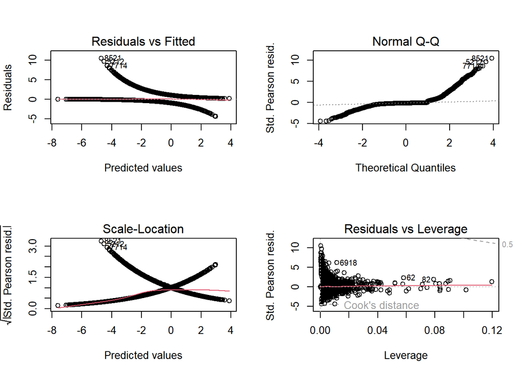

Figure 2 : Diagnostics

# 5 Model comparison

The green one appears to really improve the model compared to the one built only by the *stepAIC* function. Transforming variables also clearly improves the ROC curve and thus the model.

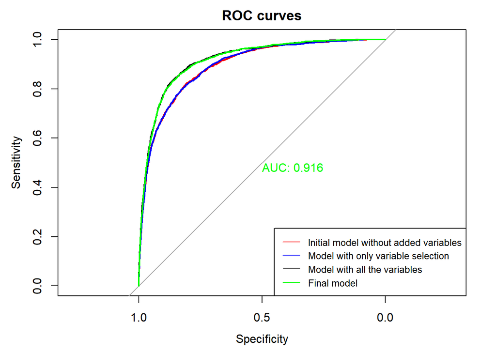

Figure 3 : ROC curves : initial model without added variables (red), model with all the variables (black), model with only variable selection (blue), final model (green)

By denoting by model0 the basis model without added variables, model1 the model with all the added variables, model2 the one obtained with *stepAIC* and model3 the final model, the performance results are as follows :

*Table 2 : Models performance results*

[output not shown]

# 6 Discussion

It’s worth noting that the clustering of variable levels was necessary to avoid having levels with insufficient data. However, collecting more data to include all levels could potentially improve the accuracy of the model even further.

# 7 References

[1] https://cmr.berkeley.edu/2018/04/facebook-ads/